# Analyzing roulette strategies

### 2.2.4 changing M value

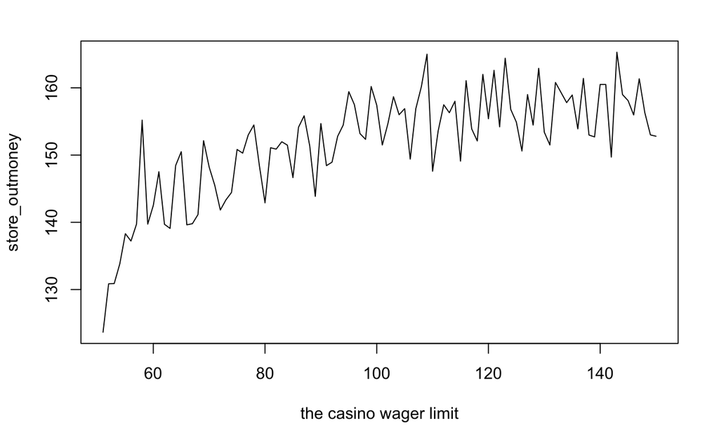

```r
#' A single play of the Martingale strategy
#'
#' Takes a state list, spins the roulette wheel, returns the state list with updated values (for example, budget, plays, etc)
#' @param state A list with the following entries:
#'   B              number, the starting budget
#'   W              number, the budget threshold for successfully stoping
#'   L              number, the maximum number of plays
#'   M              number, the casino wager limit
#'   plays          integer, the number of plays executed
#'   previous_wager number, the wager in the previous play (0 at first play)
#'   previous_win   TRUE/FALSE, indicator if the previous play was a win (TRUE at first play)
#' @return The updated state list
library(dplyr)
one_play <- function(state){

    # Wager
    proposed_wager <- ifelse(state$previous_win, 1, 2*state$previous_wager)
    wager <- min(proposed_wager, state$M, state$B)

    # Spin of the wheel
    red <- rbinom(1,1,18/38)

    # Update state
    state$plays <- state$plays + 1
    state$previous_wager <- wager
    if(red){
      # WIN
      state$B <- state$B + wager
      state$previous_win <- TRUE
    }else{
      # LOSE
      state$B <- state$B - wager
      state$previous_win <- FALSE
    }
  state
}


#' Stopping rule
#'
#' Takes the state list and determines if the gambler has to stop
#' @param state A list.  See one_play
#' @return TRUE/FALSE
stop_play <- function(state){
  if(state$B <= 0) return(TRUE)
  if(state$plays >= state$L) return(TRUE)
  if(state$B >= state$W) return(TRUE)
  FALSE
}


#' Play roulette to either bankruptcy, success, or play limits
#'
#' @param B number, the starting budget
#' @param W number, the budget threshold for successfully stoping
#' @param L number, the maximum number of plays
#' @param M number, the casino wager limit
#' @return A vector of budget values calculated after each play.
one_series <- function(
    B = 200
  , W = 300
  , L = 1000
  , M = 100
){

  # initial state
  state <- list(
    B = B
  , W = W
  , L = L
  , M = M
  , plays = 0
  , previous_wager = 0
  , previous_win = TRUE
  )

  # vector to store budget over series of plays
  budget <- rep(NA, L)

  # For loop of plays
  for(i in 1:L){
    new_state <- state %>% one_play
    budget[i] <- new_state$B
    if(new_state %>% stop_play){
      return(budget[1:i])
    }
    state <- new_state
  }
  budget
}

# helper function
get_last <- function(x) x[length(x)]


# Simulation
store_outmoney <- rep(NA, 100)
for(i in 1:100){
m=i+50 # set a oringinal value of Starting budget

walk_out_money <- rep(NA, 1000)#when walking out, person has the money ///if we want to run a plot quickly, we should set with rep()'s time is smaller interger
for(j in seq_along(walk_out_money)){
  walk_out_money[j] <- one_series(B = 200, W = 300, L = 1000, M = m) %>% get_last#get_last is function(x) x[length(x)] 's value of last one

}
store_outmoney[i] <-mean(walk_out_money)#store_outmoney contains all of mean of walk_out_money





# Estimated earnings
y=mean(walk_out_money - 200)
}
xm<- 51:150 # number, the casino wager limit is from 51 to 150.
plot(x=xm,y=store_outmoney,type="l",xlab="the casino wager limit")#draw a line chart
```

## 2.3 Question 3

Q3:See the stopping rule below. Explain to your audience how you used computer simulation to estimate the average number of plays before stopping. The code below will need to be modified to calculate this quantity.

```r
get_play <- function(x) length(x) #get_play(x) = length(x)
play_number <- rep(NA, 1000)
for(j in seq_along(play_number)){
  play_number[j] <- one_series(B = 200, W = 300, L = 1000, M = 100) %>% get_play
}
mean(play_number)
```

```
[1] 204.889
```

## 2.4 Question 4

Q4:Be sure to explain the limitations of the simulation; identify simplifications or other sources of uncertainty.

Answer:limitations of the simulation:(1)When the number of gamblers rises above 10,000 times, the computer is running too long. (2) When Starting budget(B) is closer to Winnings threshold for stopping(W), the gamblers is easier to win money at the end of game.  
Identifing simplifications:(1) Gamblers must bet until they meet stopping conditions and cannot quit the game on their own initiative. At the same time, casinos can’t ignore the stopping rules and interrupt the game.